# Reproducible Research: Peer Assessment 1

## Loading and preprocessing the data

Load library files / set the global options for the document

```r
library(knitr)
library(ggplot2)
library(lubridate)
library(dplyr)
knitr::opts_chunk$set(echo = TRUE)
```

Extracting Data, Converting the resultant data frame to tbl_df

```r
unzip("activity.zip")
dat <- read.csv("activity.csv")
dat <- tbl_df(dat)
```

## What is mean total number of steps taken per day?

1. Calculate the total number of steps taken per day

```r
by_day <- group_by(dat, date)
(by_day <- summarize(by_day, total.steps = sum(steps, na.rm = TRUE)))
```

```
## Source: local data frame [61 x 2]
##
##          date total.steps
## 1  2012-10-01           0
## 2  2012-10-02         126
## 3  2012-10-03       11352
## 4  2012-10-04       12116
## 5  2012-10-05       13294
## 6  2012-10-06       15420
## 7  2012-10-07       11015
## 8  2012-10-08           0
## 9  2012-10-09       12811
## 10 2012-10-10        9900
## ..        ...         ...
```

2. Make a histogram of the total number of steps taken each day

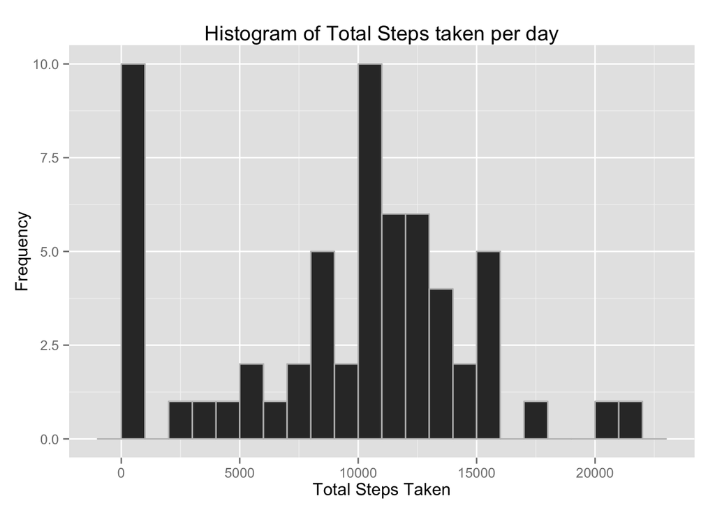

```r
ggplot(by_day, aes(total.steps)) +
        geom_histogram(binwidth = 1000, colour = "grey") +
        labs(title = "Histogram of Total Steps taken per day",
             x = "Total Steps Taken",
             y = "Frequency")
```

3. Calculate and report the mean and median of the total number of steps taken per day

```r
(mean.steps <- mean(by_day$total.steps))
```

```
## [1] 9354.23
```

```r
(median.steps <- median(by_day$total.steps))
```

```
## [1] 10395
```

Mean number of steps = 9354.2295082

Median number of steps = 10395

## What is the average daily activity pattern?

1. Make a time series plot (i.e. type = “l”) of the 5-minute interval (x-axis) and the average number of steps taken, averaged across all days (y-axis)

```r
## Group the data by time intervals
by_int <- group_by(dat, interval)
by_int <- summarise(by_int, average.steps = mean(steps, na.rm = TRUE))
```

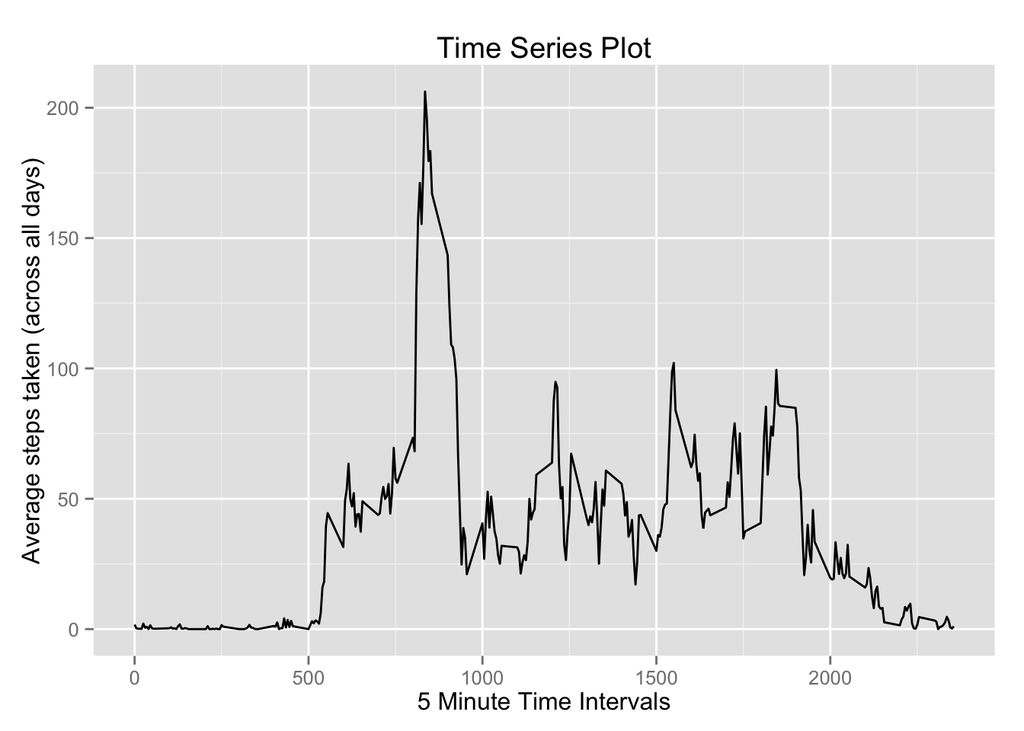

```r
## Plot Time Series graph, using ggplot
ggplot(by_int, aes(interval, average.steps)) +
        geom_line() +
        labs(title = "Time Series Plot",
             x = "5 Minute Time Intervals",
             y = "Average steps taken (across all days)")
```

2. Which 5-minute interval, on average across all the days in the dataset, contains the maximum number of steps?

```r
(max.steps <- paste(by_int[which.max(by_int$average.steps), 1]))
```

```
## [1] "835"
```

Answer: 835

## Imputing missing values

1. Calculate and report the total number of missing values in the dataset (i.e. the total number of rows with NAs)

```r
indices <- is.na(dat$steps)
(total.nas <- sum(indices))
```

```
## [1] 2304
```

Answer: 2304

2. Devise a strategy for filling in all of the missing values in the dataset. The strategy does not need to be sophisticated. For example, you could use the mean/median for that day, or the mean for that 5-minute interval, etc.

Answer: We will be filling missing values in the dataset with the mean for the respective 5-minute interval. We already computed a logical vector `indices` containing indices in the original dataset for which `steps == NA` in the previous question.

- The tbl_df object `by_int` will come handy to get values to make substitutions to the new data set
- We can use the logical vector `indices` to get the row numbers corresponding the `steps == NA`
- Running a `for` loop with the row numbers, we can substitute the NA values in the new dataset.
3. Create a new dataset that is equal to the original dataset but with the missing data filled in.

Answer: The new dataset (tbl_df object) `newdat` has been computed and printed below:

```r
a <- which(indices == TRUE)
newdat <- dat
for (i in a){
        xt <- which(by_int$interval == newdat[i, ]$interval)
        newdat[i, ]$steps <- by_int[xt,]$average.steps
        }
newdat
```

```
## Source: local data frame [17,568 x 3]
##
##        steps       date interval
## 1  1.7169811 2012-10-01        0
## 2  0.3396226 2012-10-01        5
## 3  0.1320755 2012-10-01       10
## 4  0.1509434 2012-10-01       15
## 5  0.0754717 2012-10-01       20
## 6  2.0943396 2012-10-01       25
## 7  0.5283019 2012-10-01       30
## 8  0.8679245 2012-10-01       35
## 9  0.0000000 2012-10-01       40
## 10 1.4716981 2012-10-01       45
## ..       ...        ...      ...
```

## Are there differences in activity patterns between weekdays and weekends?

1. Create a new factor variable in the dataset with two levels `weekday` and `weekend` indicating whether a given date is a weekday or weekend day.

```r
dd <- newdat
dd <- dd %>%
        mutate(day = ymd(paste(date))) %>%
        mutate(day = wday(day, label = FALSE))
dd$factor <- ifelse(dd$day >= 2 & dd$day<= 6, TRUE, FALSE)
dd[which(dd$factor == TRUE),]$factor <- "weekday"
dd[which(dd$factor == FALSE),]$factor <- "weekend"
dd$factor <- as.factor(dd$factor)
dd
```

```
## Source: local data frame [17,568 x 5]
##
##        steps       date interval day  factor
## 1  1.7169811 2012-10-01        0   2 weekday
## 2  0.3396226 2012-10-01        5   2 weekday
## 3  0.1320755 2012-10-01       10   2 weekday
## 4  0.1509434 2012-10-01       15   2 weekday
## 5  0.0754717 2012-10-01       20   2 weekday
## 6  2.0943396 2012-10-01       25   2 weekday
## 7  0.5283019 2012-10-01       30   2 weekday
## 8  0.8679245 2012-10-01       35   2 weekday
## 9  0.0000000 2012-10-01       40   2 weekday
## 10 1.4716981 2012-10-01       45   2 weekday
## ..       ...        ...      ... ...     ...
```

```r
table(dd$factor)
```

```
##
## weekday weekend
##   12960    4608
```

2. Make a panel plot containing a time series plot (i.e. type = “l”) of the 5-minute interval (x-axis) and the average number of steps taken, averaged across all weekday days or weekend days (y-axis). See the README file in the GitHub repository to see an example of what this plot should look like using simulated data.

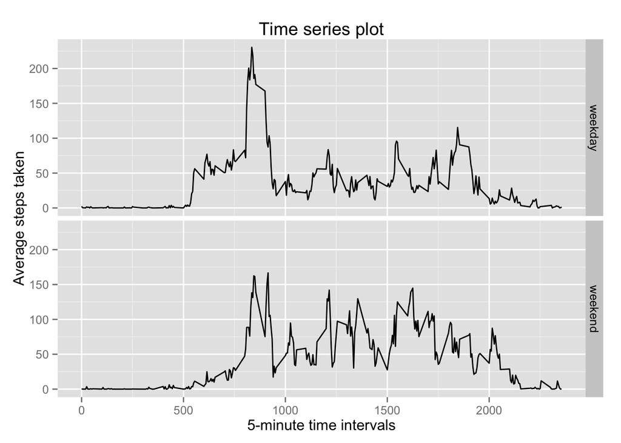

```r
gdata <- group_by(dd, factor, interval)
pdata <- summarise(gdata, avg = mean(steps))
p <- ggplot(pdata, aes(interval, avg))
p + geom_line() +
        facet_grid(factor ~.) +
        labs(title = "Time series plot",
             x = "5-minute time intervals",
             y = "Average steps taken")
```